# Exploring Air Pollution Patterns and Environmental Factors

DSC603: R Programming - Dr. Joseph Rebehmed

Team Members:** Elissa El Haber - Elissa Sbeity - Sara El Habhab

2026-05-03

# Phase 1: Data Preparation and Cleaning

## 1. Dataset Source & Motivation

This dataset was chosen because it has real sensor data that exhibits common data quality problems like missing values and data formats. It is useful in practicing data cleaning and preparation techniques in R.

**Dataset source:** https://archive.ics.uci.edu/dataset/360/air+quality

Possible research questions:

- How do air pollutant concentrations (CO, NOx, and NO₂) vary over time?
- Is there a relationship between meteorological variables (temperature, humidity) and air pollution levels?
- Are there daily or seasonal patterns in air quality measurements?
- Which pollutants show the highest variability throughout the monitoring period?
- Can environmental conditions help explain changes in pollution levels?

## 2. Data Import

The dataset was imported into R using the read_csv() function from the readr package. A copy of the raw dataset was stored to ensure that the original data remains unchanged during the cleaning process.

```r
# Load the dataset from the CSV file into R
air_raw <- read_csv("AirQualityUCI.csv")
air <- air_raw

# View first rows
head(air)
```

```
# A tibble: 6 × 15
  Date      Time   `CO(GT)` `PT08.S1(CO)` `NMHC(GT)` `C6H6(GT)` `PT08.S2(NMHC)`
  <chr>     <time>    <dbl>         <dbl>      <dbl>      <dbl>           <dbl>
1 3/10/2004 18:00       2.6          1360        150       11.9            1046
2 3/10/2004 19:00       2            1292        112        9.4             955
3 3/10/2004 20:00       2.2          1402         88        9               939
4 3/10/2004 21:00       2.2          1376         80        9.2             948
5 3/10/2004 22:00       1.6          1272         51        6.5             836
6 3/10/2004 23:00       1.2          1197         38        4.7             750
# ℹ 8 more variables: `NOx(GT)` <dbl>, `PT08.S3(NOx)` <dbl>, `NO2(GT)` <dbl>,
#   `PT08.S4(NO2)` <dbl>, `PT08.S5(O3)` <dbl>, T <dbl>, RH <dbl>, AH <dbl>
```

## 3. Data Structure Inspection

After importing the dataset, an initial inspection was performed to understand the structure of the data. This included examining the variable types, summary statistics, dimensions of the dataset, and the column names.

```r
# Examine the structure of the dataset and data types of each column
glimpse(air)
```

```
Rows: 9,357
Columns: 15
$ Date            <chr> "3/10/2004", "3/10/2004", "3/10/2004", "3/10/2004", "3…
$ Time            <time> 18:00:00, 19:00:00, 20:00:00, 21:00:00, 22:00:00, 23:…
$ `CO(GT)`        <dbl> 2.6, 2.0, 2.2, 2.2, 1.6, 1.2, 1.2, 1.0, 0.9, 0.6, -200…
$ `PT08.S1(CO)`   <dbl> 1360, 1292, 1402, 1376, 1272, 1197, 1185, 1136, 1094, …
$ `NMHC(GT)`      <dbl> 150, 112, 88, 80, 51, 38, 31, 31, 24, 19, 14, 8, 16, 2…
$ `C6H6(GT)`      <dbl> 11.9, 9.4, 9.0, 9.2, 6.5, 4.7, 3.6, 3.3, 2.3, 1.7, 1.3…
$ `PT08.S2(NMHC)` <dbl> 1046, 955, 939, 948, 836, 750, 690, 672, 609, 561, 527…
$ `NOx(GT)`       <dbl> 166, 103, 131, 172, 131, 89, 62, 62, 45, -200, 21, 16,…
$ `PT08.S3(NOx)`  <dbl> 1056, 1174, 1140, 1092, 1205, 1337, 1462, 1453, 1579, …
$ `NO2(GT)`       <dbl> 113, 92, 114, 122, 116, 96, 77, 76, 60, -200, 34, 28, …
$ `PT08.S4(NO2)`  <dbl> 1692, 1559, 1555, 1584, 1490, 1393, 1333, 1333, 1276, …
$ `PT08.S5(O3)`   <dbl> 1268, 972, 1074, 1203, 1110, 949, 733, 730, 620, 501, …
$ T               <dbl> 13.6, 13.3, 11.9, 11.0, 11.2, 11.2, 11.3, 10.7, 10.7, …
$ RH              <dbl> 48.9, 47.7, 54.0, 60.0, 59.6, 59.2, 56.8, 60.0, 59.7, …
$ AH              <dbl> 0.7578, 0.7255, 0.7502, 0.7867, 0.7888, 0.7848, 0.7603…
```

The structure of the dataset shows the data types of each variable. Most variables are numerical measurements from environmental sensors, while the Date variable is initially stored as character values.

```r
# Generate summary statistics for each variable
summary(air)
```

```
     Date                Time                     CO(GT)         PT08.S1(CO)
 Length:9357        Min.   :00:00:00.000000   Min.   :-200.00   Min.   :-200
 Class :character   1st Qu.:05:00:00.000000   1st Qu.:   0.60   1st Qu.: 921
 Mode  :character   Median :11:00:00.000000   Median :   1.50   Median :1053
                    Mean   :11:29:54.806028   Mean   : -34.21   Mean   :1049
                    3rd Qu.:18:00:00.000000   3rd Qu.:   2.60   3rd Qu.:1221
                    Max.   :23:00:00.000000   Max.   :  11.90   Max.   :2040
    NMHC(GT)         C6H6(GT)        PT08.S2(NMHC)       NOx(GT)
 Min.   :-200.0   Min.   :-200.000   Min.   :-200.0   Min.   :-200.0
 1st Qu.:-200.0   1st Qu.:   4.000   1st Qu.: 711.0   1st Qu.:  50.0
 Median :-200.0   Median :   7.900   Median : 895.0   Median : 141.0
 Mean   :-159.1   Mean   :   1.866   Mean   : 894.6   Mean   : 168.6
 3rd Qu.:-200.0   3rd Qu.:  13.600   3rd Qu.:1105.0   3rd Qu.: 284.0
 Max.   :1189.0   Max.   :  63.700   Max.   :2214.0   Max.   :1479.0
  PT08.S3(NOx)     NO2(GT)         PT08.S4(NO2)   PT08.S5(O3)
 Min.   :-200   Min.   :-200.00   Min.   :-200   Min.   :-200.0
 1st Qu.: 637   1st Qu.:  53.00   1st Qu.:1185   1st Qu.: 700.0
 Median : 794   Median :  96.00   Median :1446   Median : 942.0
 Mean   : 795   Mean   :  58.15   Mean   :1391   Mean   : 975.1
 3rd Qu.: 960   3rd Qu.: 133.00   3rd Qu.:1662   3rd Qu.:1255.0
 Max.   :2683   Max.   : 340.00   Max.   :2775   Max.   :2523.0
       T                  RH                AH
 Min.   :-200.000   Min.   :-200.00   Min.   :-200.0000
 1st Qu.:  10.900   1st Qu.:  34.10   1st Qu.:   0.6923
 Median :  17.200   Median :  48.60   Median :   0.9768
 Mean   :   9.778   Mean   :  39.49   Mean   :  -6.8376
 3rd Qu.:  24.100   3rd Qu.:  61.90   3rd Qu.:   1.2962
 Max.   :  44.600   Max.   :  88.70   Max.   :   2.2310
```

The summary statistics provide an overview of the distribution of each variable, including minimum, maximum, mean, and quartile values. Some unusual values appear due to missing values coded as -200.

```r
# Check the number of rows and columns
dim(air)
```

```
[1] 9357   15
```

The dataset contains 9,357 observations (rows) and 15 variables (columns).

```r
# Display the names of all variables in the dataset
colnames(air)
```

```
 [1] "Date"          "Time"          "CO(GT)"        "PT08.S1(CO)"
 [5] "NMHC(GT)"      "C6H6(GT)"      "PT08.S2(NMHC)" "NOx(GT)"
 [9] "PT08.S3(NOx)"  "NO2(GT)"       "PT08.S4(NO2)"  "PT08.S5(O3)"
[13] "T"             "RH"            "AH"
```

This output shows the names of all variables in the dataset, allowing us to check for any inconsistencies or formatting issues in the column names.

## 4. Issues Identified

The initial inspection of the provided dataset showed some issues that need to be addressed before moving on to the next steps. The identification of these issues is an essential part of the process that ensures the quality and accuracy of the provided information. The identified issues during the exploration stage are listed below:

- The missing value indicator is set to the value -200, and the minimum value for some variables in the summary statistics is represented by the value -200.
- The Date variable is stored as character variable rather than date format.
- The dataset contains separate Date and Time columns, which makes chronological analysis less convenient and requires combining them into a single timestamp variable.
- Some of the summary statistics are not realistic (for example, the mean value is negative), mainly because the placeholder value -200 is part of the calculations.
- Some of the column names include special characters (for example, CO(GT), NOx(GT)), which makes the code less readable.

## 5. Data Cleaning

### 5.1 Handling Encoded Missing Values

According to the dataset documentation, missing observations are represented by the value -200. Since R does not automatically recognize this value as missing data, these entries must be replaced with NA to allow proper handling during analysis.

```r
# Replace -200 placeholders with NA
air[air == -200] <- NA

# Check missing values per column
# Identify columns that contain NA values
na_cols <- names(air)[colSums(is.na(air)) > 0]
na_cols
```

```
 [1] "CO(GT)"        "PT08.S1(CO)"   "NMHC(GT)"      "C6H6(GT)"
 [5] "PT08.S2(NMHC)" "NOx(GT)"       "PT08.S3(NOx)"  "NO2(GT)"
 [9] "PT08.S4(NO2)"  "PT08.S5(O3)"   "T"             "RH"
[13] "AH"
```

### 5.2 Duplicate Observations

The dataset was examined for duplicate rows to ensure that each observation represents a unique measurement. Removing duplicates prevents repeated entries from influencing summary statistics and subsequent analysis.

```r
# Count duplicate rows
sum(duplicated(air))
```

```
[1] 0
```

```r
# Remove duplicates if any
air <- air %>% distinct()
```

### 5.3 Standardizing Column Names

Some variable names contained punctuation and special characters that reduce readability and may complicate data manipulation. To improve clarity and consistency, column names were standardized into a simpler and more readable format.

```r
# Standardize column names to improve readability
air <- air %>%
  rename(
    CO_GT        = `CO(GT)`,
    PT08_S1_CO   = `PT08.S1(CO)`,
    NMHC_GT      = `NMHC(GT)`,
    C6H6_GT      = `C6H6(GT)`,
    PT08_S2_NMHC = `PT08.S2(NMHC)`,
    NOx_GT       = `NOx(GT)`,
    PT08_S3_NOx  = `PT08.S3(NOx)`,
    NO2_GT       = `NO2(GT)`,
    PT08_S4_NO2  = `PT08.S4(NO2)`,
    PT08_S5_O3   = `PT08.S5(O3)`,
    Temperature       = T,
    Relative_Humidity = RH,
    Absolute_Humidity = AH
  )

# Check
colnames(air)
```

```
 [1] "Date"              "Time"              "CO_GT"
 [4] "PT08_S1_CO"        "NMHC_GT"           "C6H6_GT"
 [7] "PT08_S2_NMHC"      "NOx_GT"            "PT08_S3_NOx"
[10] "NO2_GT"            "PT08_S4_NO2"       "PT08_S5_O3"
[13] "Temperature"       "Relative_Humidity" "Absolute_Humidity"
```

### 5.4 Converting Date and Time Variables

The Date variable was initially stored as a character string, which prevents it from being used directly in time-based analyses. To resolve this issue, the variable was converted into a proper date format. In addition, a new variable named DateTime was created to represent the complete timestamp of each observation, enabling easier chronological analysis of the air quality measurements.

```r
# Convert Date
air$Date <- as.Date(air$Date, format = "%m/%d/%Y")

# Create DateTime variable
air$DateTime <- as.POSIXct(paste(air$Date, air$Time), format = "%Y-%m-%d %H:%M:%S")

# Remove Time column
air <- air %>% select(-Time)
```

### 5.5 Missing Value Assessment

After replacing the encoded missing values with NA, the number of missing observations in each column was calculated. This step helps identify variables with significant missing data and informs the choice of imputation methods.

```r
# Count the number of missing values (NA) in each column of the dataset
colSums(is.na(air))
```

```
             Date             CO_GT        PT08_S1_CO           NMHC_GT
                0              1683               366              8443
          C6H6_GT      PT08_S2_NMHC            NOx_GT       PT08_S3_NOx
              366               366              1639               366
           NO2_GT       PT08_S4_NO2        PT08_S5_O3       Temperature
             1642               366               366               366
Relative_Humidity Absolute_Humidity          DateTime
              366               366                 2
```

### 5.6 Distribution Analysis

The distributions of numerical variables containing missing values were examined using histograms. Visualizing the distributions helps determine whether the mean or median is a more appropriate method for imputing missing values.

```r
na_cols <- names(air)[colSums(is.na(air)) > 0]
na_cols
```

```
 [1] "CO_GT"             "PT08_S1_CO"        "NMHC_GT"
 [4] "C6H6_GT"           "PT08_S2_NMHC"      "NOx_GT"
 [7] "PT08_S3_NOx"       "NO2_GT"            "PT08_S4_NO2"
[10] "PT08_S5_O3"        "Temperature"       "Relative_Humidity"
[13] "Absolute_Humidity" "DateTime"
```

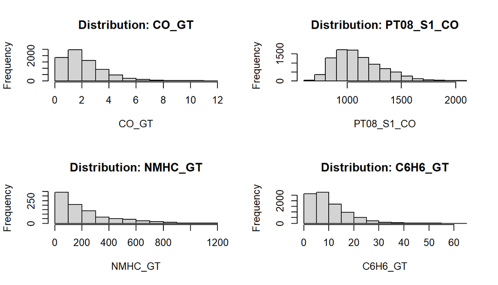

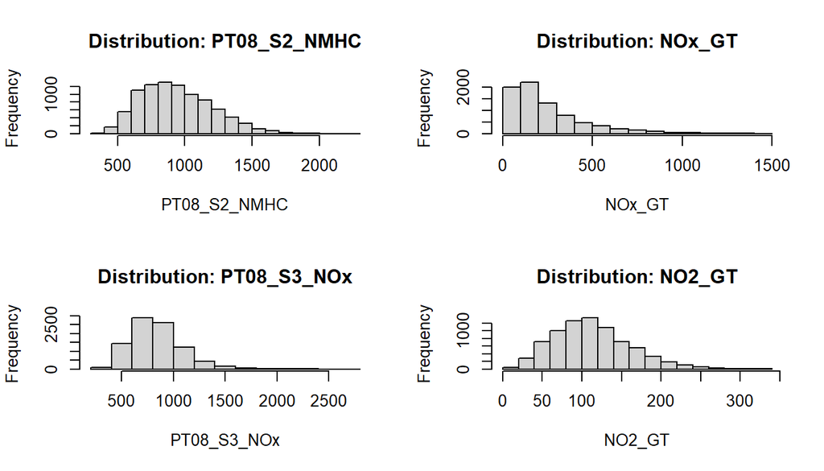

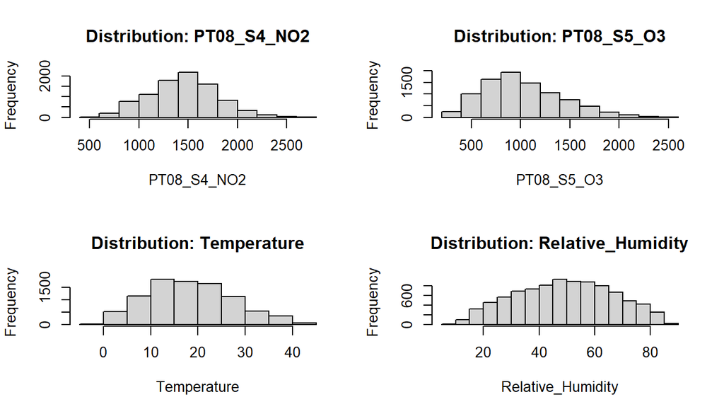

```r
# Visualize the distribution of variables with missing values
num_na_cols <- na_cols[sapply(na_cols, function(col) is.numeric(air[[col]]))]
par(mfrow = c(2,2))
for (col in num_na_cols) {
  hist(air[[col]],
       main = paste("Distribution:", col),
       xlab = col)
}
```

[figure not shown]

```r
par(mfrow = c(1,1))
```

### 5.7 Missing Value Imputation

Missing values were replaced using statistical imputation techniques. Depending on the distribution of each variable, either the mean or the median was used to substitute missing observations. This approach preserves the overall structure of the data while minimizing the impact of missing values.

```r
# Loop through each numeric column that contains missing values
for (col in num_na_cols) {

  x   <- air[[col]]
  m   <- mean(x, na.rm = TRUE)
  med <- median(x, na.rm = TRUE)
  s   <- sd(x, na.rm = TRUE)

  use_median <- abs(m - med) > 0.25 * s
  fill_value <- if (use_median) med else m

  air[[col]][is.na(air[[col]])] <- fill_value
}
```

### 5.8 Removal of Invalid Time Records

Rows with missing or invalid DateTime values were removed from the dataset, since accurate time information is necessary for analyzing temporal patterns in air quality measurements.

```r
# Remove rows where the DateTime variable is missing (NA)
air <- air %>%
  filter(!is.na(DateTime))
```

## 6. Cleaned Dataset Overview

After completing the data cleaning procedures, the dataset was inspected again to confirm that the identified issues had been successfully addressed. This step ensures that missing values, data types, and structural inconsistencies have been properly handled.

Basic descriptive statistics and the structure of the cleaned dataset were examined to verify that the dataset is ready for further analysis.

```r
dim(air)
```

```
[1] 9355   15
```

```r
colSums(is.na(air))
```

```
             Date             CO_GT        PT08_S1_CO           NMHC_GT
                0                 0                 0                 0
          C6H6_GT      PT08_S2_NMHC            NOx_GT       PT08_S3_NOx
                0                 0                 0                 0
           NO2_GT       PT08_S4_NO2        PT08_S5_O3       Temperature
                0                 0                 0                 0
Relative_Humidity Absolute_Humidity          DateTime
                0                 0                 0
```

```r
glimpse(air)
```

```
Rows: 9,355
Columns: 15
$ Date              <date> 2004-03-10, 2004-03-10, 2004-03-10, 2004-03-10, 200…
$ CO_GT             <dbl> 2.60000, 2.00000, 2.20000, 2.20000, 1.60000, 1.20000…
$ PT08_S1_CO        <dbl> 1360, 1292, 1402, 1376, 1272, 1197, 1185, 1136, 1094…
$ NMHC_GT           <dbl> 150, 112, 88, 80, 51, 38, 31, 31, 24, 19, 14, 8, 16,…
$ C6H6_GT           <dbl> 11.9, 9.4, 9.0, 9.2, 6.5, 4.7, 3.6, 3.3, 2.3, 1.7, 1…
$ PT08_S2_NMHC      <dbl> 1046, 955, 939, 948, 836, 750, 690, 672, 609, 561, 5…
$ NOx_GT            <dbl> 166, 103, 131, 172, 131, 89, 62, 62, 45, 180, 21, 16…
$ PT08_S3_NOx       <dbl> 1056, 1174, 1140, 1092, 1205, 1337, 1462, 1453, 1579…
$ NO2_GT            <dbl> 113.0000, 92.0000, 114.0000, 122.0000, 116.0000, 96.…
$ PT08_S4_NO2       <dbl> 1692, 1559, 1555, 1584, 1490, 1393, 1333, 1333, 1276…
$ PT08_S5_O3        <dbl> 1268, 972, 1074, 1203, 1110, 949, 733, 730, 620, 501…
$ Temperature       <dbl> 13.6, 13.3, 11.9, 11.0, 11.2, 11.2, 11.3, 10.7, 10.7…
$ Relative_Humidity <dbl> 48.9, 47.7, 54.0, 60.0, 59.6, 59.2, 56.8, 60.0, 59.7…
$ Absolute_Humidity <dbl> 0.7578, 0.7255, 0.7502, 0.7867, 0.7888, 0.7848, 0.76…
$ DateTime          <dttm> 2004-03-10 18:00:00, 2004-03-10 19:00:00, 2004-03-1…
```

```r
summary(air)
```

```
      Date                CO_GT          PT08_S1_CO      NMHC_GT
 Min.   :2004-03-10   Min.   : 0.100   Min.   : 647   Min.   :   7.0
 1st Qu.:2004-06-16   1st Qu.: 1.200   1st Qu.: 941   1st Qu.: 150.0
 Median :2004-09-21   Median : 2.153   Median :1075   Median : 150.0
 Mean   :2004-09-21   Mean   : 2.153   Mean   :1100   Mean   : 156.7
 3rd Qu.:2004-12-28   3rd Qu.: 2.600   3rd Qu.:1221   3rd Qu.: 150.0
 Max.   :2005-04-04   Max.   :11.900   Max.   :2040   Max.   :1189.0
    C6H6_GT       PT08_S2_NMHC        NOx_GT        PT08_S3_NOx
 Min.   : 0.10   Min.   : 383.0   Min.   :   2.0   Min.   : 322.0
 1st Qu.: 4.60   1st Qu.: 742.5   1st Qu.: 112.0   1st Qu.: 666.0
 Median : 8.20   Median : 923.0   Median : 180.0   Median : 818.0
 Mean   :10.01   Mean   : 939.2   Mean   : 235.2   Mean   : 835.5
 3rd Qu.:13.60   3rd Qu.:1105.0   3rd Qu.: 284.0   3rd Qu.: 960.0
 Max.   :63.70   Max.   :2214.0   Max.   :1479.0   Max.   :2683.0
     NO2_GT       PT08_S4_NO2     PT08_S5_O3    Temperature
 Min.   :  2.0   Min.   : 551   Min.   : 221   Min.   :-1.90
 1st Qu.: 86.0   1st Qu.:1242   1st Qu.: 742   1st Qu.:12.00
 Median :113.1   Median :1456   Median : 983   Median :18.30
 Mean   :113.1   Mean   :1456   Mean   :1023   Mean   :18.32
 3rd Qu.:133.0   3rd Qu.:1662   3rd Qu.:1256   3rd Qu.:24.10
 Max.   :340.0   Max.   :2775   Max.   :2523   Max.   :44.60
 Relative_Humidity Absolute_Humidity    DateTime
 Min.   : 9.20     Min.   :0.1847    Min.   :2004-03-10 18:00:00
 1st Qu.:36.60     1st Qu.:0.7461    1st Qu.:2004-06-16 05:30:00
 Median :49.23     Median :1.0154    Median :2004-09-21 16:00:00
 Mean   :49.23     Mean   :1.0255    Mean   :2004-09-21 16:23:56
 3rd Qu.:61.90     3rd Qu.:1.2964    3rd Qu.:2004-12-28 02:30:00
 Max.   :88.70     Max.   :2.2310    Max.   :2005-04-04 14:00:00
```

## 7. Exporting the Clean Dataset

To preserve the integrity of the original dataset, the cleaned version was saved as a new CSV file. This allows the cleaned dataset to be reused in future analyses without modifying the raw data.

```r
write_csv(air, "AirQualityUCI_clean.csv")
```

## 8. Written Summary

As the dataset is imported into R for analysis, several problems were identified in the dataset. These include the presence of encoded missing values in the dataset, where missing values are encoded using -200. Additionally, the dataset has inconsistent data types and special characters in the column names. The Date variable in the dataset is stored as a character variable and therefore requires conversion into the correct date format for analysis in the subsequent phases of the project.

A series of data cleaning procedures were performed on the Air Quality dataset. These include the replacement of encoded missing values with NA values, the standardization of the column names for better readability, and the conversion of the Date variable into the correct date format. Additionally, a new variable named DateTime is created for the complete timestamp of the observations in the dataset.

Missing values were then analyzed and replaced using either the mean or the median, depending on the distribution of each variable. Two observations containing missing DateTime values were removed because time information is essential for temporal analysis.

After completing these steps, the dataset contained consistent variable formats and properly handled missing values. The cleaned dataset was exported as a new file so that the original raw data remains unchanged and the prepared dataset can be used for further analysis in later phases of the project.

## ───────────────────────

# Phase 2: Exploratory Data Visualization and Insights

## 9. Introduction

After completing the data cleaning in Phase 1, the dataset is now fully structured, consistent, and free from missing value issues, making it suitable for further analysis.

The second phase of this project focuses on transforming the cleaned Air Quality dataset into meaningful and interactive visualizations. These visualizations are designed to reveal underlying patterns in the data, including temporal trends, relationships between environmental variables, distributional characteristics, and variability in air pollution levels.

A set of appropriate visualization techniques was carefully selected to address the research questions and ensure that the insights extracted from the dataset are clear, interpretable, and data-driven.

## 10. Visualization Setup

```r
# Consistent color theme for all plots
colors_theme <- list(
  co  = "#E63946",   # red for CO
  no2 = "#457B9D",   # blue for NO2
  nox = "#2A9D8F",   # green for NOx
  background = "white",   # plot background
  grid = "#EAEAEA"        # grid lines
)

# Create features
air <- air %>%
  mutate(
    Hour      = hour(DateTime),
    Month     = month(DateTime, label = TRUE, abbr = TRUE),
    Date_only = as.Date(DateTime),
    Season    = case_when(
      month(DateTime) %in% c(12, 1, 2) ~ "Winter",
      month(DateTime) %in% c(3, 4, 5)  ~ "Spring",
      month(DateTime) %in% c(6, 7, 8)  ~ "Summer",
      TRUE ~ "Autumn"
    ),
    Season = factor(Season, levels = c("Winter", "Spring", "Summer", "Autumn"))
  )
```

## 11. Plot 1: Monthly Trend of Major Air Pollutants

**Why this visualization?**

A multi-panel line chart was chosen to observe long-term temporal trends across different pollutants simultaneously. By using separate y-axes in a stacked layout, we can compare the peaks and valleys of CO, NO₂, and NOx without the scale of one pollutant (like NOx) flattening the others.

**Insights:**

The visualization reveals that pollutant levels are not static; they exhibit significant seasonal fluctuations. Specifically, CO and NOx show synchronized peaks during the colder months, suggesting that atmospheric stagnation or increased heating emissions may influence air quality during these periods.

**Customization:**

- Interactive Tooltips: Custom hover text provides precise average values for each month, allowing for a level of detail that static lines cannot offer.
- Color Consistency: Colors were mapped to specific pollutants (Red for CO, Blue for NO₂, Green for NOx) to create a visual “shorthand” used throughout the entire report.

```r
# Prepare monthly data (aggregate raw hourly data into monthly averages)
monthly_pollution <- air %>%
  mutate(Month_Date = floor_date(Date_only, unit = "month")) %>%  # extract month from date
  group_by(Month_Date) %>%
  summarise(
    CO_GT  = mean(CO_GT,  na.rm = TRUE),   # average CO per month
    NOx_GT = mean(NOx_GT, na.rm = TRUE),  # average NOx per month
    NO2_GT = mean(NO2_GT, na.rm = TRUE),  # average NO2 per month
    .groups = "drop"
  ) %>%
  pivot_longer(
    cols = c(CO_GT, NOx_GT, NO2_GT),  # reshape data to long format for plotting
    names_to  = "Pollutant",
    values_to = "Average_Value"
  ) %>%
  mutate(
    Pollutant = dplyr::recode(
      Pollutant,
      "CO_GT"  = "CO(GT)",
      "NO2_GT" = "NO2(GT)",
      "NOx_GT" = "NOx(GT)"
    )  # rename pollutants for readability
  )

# Split dataset by pollutant (one dataset per subplot)
co_data  <- monthly_pollution %>% filter(Pollutant == "CO(GT)")
no2_data <- monthly_pollution %>% filter(Pollutant == "NO2(GT)")
nox_data <- monthly_pollution %>% filter(Pollutant == "NOx(GT)")

# Create hover text for interactivity
co_text  <- paste("Pollutant: CO(GT)", "<br>Month:", format(co_data$Month_Date, "%b %Y"),
                  "<br>Average:", round(co_data$Average_Value, 2))
no2_text <- paste("Pollutant: NO2(GT)", "<br>Month:", format(no2_data$Month_Date, "%b %Y"),
                  "<br>Average:", round(no2_data$Average_Value, 2))
nox_text <- paste("Pollutant: NOx(GT)", "<br>Month:", format(nox_data$Month_Date, "%b %Y"),
                  "<br>Average:", round(nox_data$Average_Value, 2))

# CO subplot
p1 <- plot_ly(
  data = co_data, x = ~Month_Date, y = ~Average_Value,
  type = "scatter", mode = "lines+markers",
  text = co_text, hoverinfo = "text",
  name = "CO(GT)",
  legendgroup = "CO",
  line = list(color = colors_theme$co, width = 3),
  marker = list(color = colors_theme$co, size = 6),
  showlegend = TRUE
)

# NO2 subplot
p2 <- plot_ly(
  data = no2_data, x = ~Month_Date, y = ~Average_Value,
  type = "scatter", mode = "lines+markers",
  text = no2_text, hoverinfo = "text",
  name = "NO2(GT)",
  legendgroup = "NO2",
  line = list(color = colors_theme$no2, width = 3),
  marker = list(color = colors_theme$no2, size = 6),
  showlegend = TRUE
)

# NOx subplot
p3 <- plot_ly(
  data = nox_data, x = ~Month_Date, y = ~Average_Value,
  type = "scatter", mode = "lines+markers",
  text = nox_text, hoverinfo = "text",
  name = "NOx(GT)",
  legendgroup = "NOx",
  line = list(color = colors_theme$nox, width = 3),
  marker = list(color = colors_theme$nox, size = 6),
  showlegend = TRUE
)

# Combine all three plots
subplot(
  p1, p2, p3,
  nrows = 3,
  shareX = TRUE,
  titleY = TRUE
) %>%
layout(
  title = list(
    text = "<b>Monthly Trends of Major Air Pollutants (CO, NO2, NOx)</b>",
    x = 0.5
  ),
  legend = list(
    orientation = "v",
    y = 0.5,
    x = 1.05
  ),
  margin = list(r = 100)
)
```

[interactive chart not shown]

**Figure 1.** Monthly trends of CO(GT), NO2(GT), and NOx(GT). The three panels highlight how pollutant concentrations change over time, revealing seasonal fluctuations and long-term variations in air quality.

## 12. Plot 2: Relationship Between Weather Conditions and NO2

**Why this visualization?**

A scatter plot is the most effective way to identify correlations between continuous variables. By plotting Temperature against Humidity and layering NO₂ levels as a color dimension, we can explore how meteorological conditions collectively influence pollution intensity.

**Insights:**

The plot indicates a negative correlation between temperature and NO₂; as temperatures drop, the concentration of NO₂ increases (visible as a cluster of red points in the lower-temperature range). This suggests that cooler weather may trap pollutants closer to the ground.

**Customization:**

- Continuous Color Gradient: A “Skyblue-to-Red” colorscale was implemented to intuitively represent the transition from safe to high pollution levels.
- Transparency (Opacity): Setting marker opacity to 0.7 prevents overplotting, allowing the density of the data points to remain visible in crowded areas.

[interactive chart not shown]

**Figure 2.** Relationship between temperature, relative humidity, and NO2 concentration. Points are colored by NO2 levels to highlight how atmospheric conditions may influence pollution intensity.

## 13. Plot 3: Average NOx Concentration by Hour

**Why this visualization?**

A line chart with an area fill was selected to highlight the “volume” of pollution across a standard 24-hour cycle. This format makes it easy for the viewer to identify “rush hour” patterns and the duration of peak exposure times.

**Insights:**

The data reveals a clear bimodal distribution (two peaks). Significant spikes occur around 8:00 AM and 6:00 PM, aligning with typical morning and evening commuting hours. This strongly suggests that vehicular traffic is a major contributor to NOx emissions.

The dashed reference line represents the overall average NOx concentration, allowing for easy identification of hours with above-average pollution levels. Additionally, the shaded region highlights periods where NOx concentrations exceed a defined threshold, indicating high pollution conditions.

**Customization:**

- Area Fill: A semi-transparent green fill emphasizes the magnitude and continuity of pollution levels throughout the day.
- Mean Reference Line: A dashed horizontal line was added to represent the average NOx level, providing a baseline for comparison.
- Threshold Highlighting: A shaded red region was introduced to indicate high pollution levels above a specified threshold (200), improving interpretability of critical periods.
- Interactive Hover: Users can hover over the plot to view exact hourly values, enabling precise inspection of peak pollution times.

```r
# Compute average NOx concentration for each hour of the day
hourly_nox <- air %>%
  group_by(Hour) %>%
  summarise(Avg_NOx = mean(NOx_GT, na.rm = TRUE), .groups = "drop")

# Compute overall mean NOx level across all hours
mean_nox <- mean(hourly_nox$Avg_NOx, na.rm = TRUE)

# Define pollution threshold for high NOx levels
threshold <- 200

# Identify the hour with the highest NOx concentration
peak <- hourly_nox %>% filter(Avg_NOx == max(Avg_NOx))

# Create main NOx hourly trend plot
plot_ly(
  data = hourly_nox,
  x = ~Hour,
  y = ~Avg_NOx,
  type = "scatter",
  mode = "lines",
  name = "NOx (Avg)",
  fill = "tozeroy",
  fillcolor = paste0(colors_theme$nox, "4D"),
  line = list(color = colors_theme$nox, width = 3)
) %>%

  # Add mean NOx reference line
  add_lines(
    y = rep(mean_nox, nrow(hourly_nox)),
    name = "Mean NOx",
    line = list(dash = "dash", color = "black", width = 2)
  ) %>%

  # Highlight peak pollution hour
  add_markers(
    data = peak,
    x = ~Hour,
    y = ~Avg_NOx,
    marker = list(size = 10, color = "red"),
    name = "Peak Hour"
  ) %>%

  # Add threshold reference line
  add_trace(
    data = hourly_nox,
    x = ~Hour,
    y = ~rep(threshold, nrow(hourly_nox)),
    type = "scatter",
    mode = "lines",
    name = "High Pollution Threshold (200)",
    line = list(color = "rgba(255,0,0,0)", width = 1),
    hoverinfo = "text",
    text = "Red shaded area = NOx above safe threshold (200)"
  ) %>%

  # Final layout styling
  layout(
    title = list(
      text = "<b>Daily NOx Concentration Pattern (Hourly Analysis)</b>",
      x = 0.5
    ),

    # Highlight high pollution region visually
    shapes = list(
      list(
        type = "rect",
        x0 = 0, x1 = 23,
        y0 = threshold,
        y1 = max(hourly_nox$Avg_NOx),
        fillcolor = "rgba(255,0,0,0.12)",
        line = list(width = 0)
      )
    ),

    # Move legend to the right side of the plot
    legend = list(
      orientation = "v",
      x = 1.02,
      y = 1,
      xanchor = "left",
      yanchor = "top"
    )
  )
```

[interactive chart not shown]

**Figure 3.** Average NOx concentration by hour of the day. The curve shows daily pollution patterns and identifies peak emission periods.

## 14. Plot 4: Seasonal Distribution of CO

**Why this visualization?**

A box plot was chosen to analyze how carbon monoxide (CO) concentrations vary across seasons. Unlike mean-based charts, box plots provide a complete statistical summary including median, interquartile range, and outliers, allowing for a more robust understanding of variability and extreme pollution events.

To complement this, seasonal mean values were added as reference markers, enabling a direct comparison between central tendency (mean) and distribution behavior (median and spread).

**Insights:**

The visualization shows that while the median level of CO is relatively consistent across seasons, Winter and Autumn exhibit much higher variability and more frequent extreme outliers. This indicates that pollution events are more unpredictable during these seasons compared to the relatively stable Summer months.

**Customization:**

- Categorical Coloring: Each season is assigned a distinct color to make the comparison immediate and visually scannable.
- Interactive Outlier Inspection: Plotly allows the user to hover over individual outliers to see the specific CO value, rather than just seeing a generic dot.
- Box Plot Distribution: Captures median, quartiles, and outliers for a complete statistical view of CO levels.
- Seasonal Mean Markers: Black points represent the mean CO concentration for each season, providing a direct comparison against the median.

```r
# Create boxplot to show CO distribution across seasons
plot_ly(
  data = air,
  x = ~Season,
  y = ~CO_GT,
  color = ~Season,
  type = "box",
  colors = c(
  "Winter" = "#8DA9C4",
  "Spring" = "#A8D5BA",
  "Summer" = "#F6C89F",
  "Autumn" = "#E6A4A4"
  )
) %>%

  # Add mean CO value per season as black markers
  add_markers(
    data = air %>%
      group_by(Season) %>%
      summarise(mean_CO = mean(CO_GT, na.rm = TRUE)),
    x = ~Season,
    y = ~mean_CO,
    marker = list(color = "black", size = 8),
    name = "Mean",
    showlegend = TRUE,
    inherit = FALSE
  ) %>%
  layout(
    title = list(
      text = "<b>Seasonal Variation of CO Concentrations</b>",
      x = 0.5
    )
  )
```

[interactive chart not shown]

**Figure 4.** Seasonal distribution of CO(GT) levels using box plots. This visualization compares pollution variability across winter, spring, summer, and autumn.

## 15. Plot 5: Pollutant Variability

**Why this visualization?**

A violin plot was selected because it combines a box plot with a kernel density estimation. This allows us to see not just the range of the pollutants (CO, NOx, NO₂), but also where the “bulk” of the data points are clustered.

**Insights:**

The violin plots highlight a massive disparity in variability. While CO and NO₂ have relatively narrow “necks,” NOx shows a very wide spread with a long upward tail. This indicates that NOx is highly volatile and prone to extreme concentration spikes that far exceed the typical range of other pollutants.

**Customization:**

- Embedded Box Plots: Including the box plot inside the violin provides the best of both worlds: the precise quartiles of the box plot and the distributional shape of the violin.
- Coordinated Palette: Reusing the Green/Blue/Red palette ensures the reader can immediately identify which pollutant is which without constantly checking the legend.

```r
# Create the object inside the chunk
pollutant_long <- air %>%
  select(CO_GT, NOx_GT, NO2_GT) %>%
  pivot_longer(
    everything(),
    names_to  = "Pollutant",
    values_to = "Value"
  ) %>%
  mutate(
    Pollutant = dplyr::recode(
      Pollutant,
      "CO_GT"  = "CO(GT)",
      "NOx_GT" = "NOx(GT)",
      "NO2_GT" = "NO2(GT)"
    )
  )

# Filter for subplots
co_dist  <- pollutant_long %>% filter(Pollutant == "CO(GT)")
no2_dist <- pollutant_long %>% filter(Pollutant == "NO2(GT)")
nox_dist <- pollutant_long %>% filter(Pollutant == "NOx(GT)")

# Create individual plots
p_co <- plot_ly(data = co_dist, x = ~Pollutant, y = ~Value, type = "violin",
                name = "CO(GT)", marker = list(color = colors_theme$co),
                line = list(color = colors_theme$co), fillcolor = colors_theme$co)

p_no2 <- plot_ly(data = no2_dist, x = ~Pollutant, y = ~Value, type = "violin",
                 name = "NO2(GT)", marker = list(color = colors_theme$no2),
                 line = list(color = colors_theme$no2), fillcolor = colors_theme$no2)

p_nox <- plot_ly(data = nox_dist, x = ~Pollutant, y = ~Value, type = "violin",
                 name = "NOx(GT)", marker = list(color = colors_theme$nox),
                 line = list(color = colors_theme$nox), fillcolor = colors_theme$nox)

# Generate Subplot
subplot(p_co, p_no2, p_nox, nrows = 1, shareY = FALSE, margin = 0.05) %>%
  layout(
    title = list(text = "<b>Distribution of Major Air Pollutants</b>", x = 0.5),
    showlegend = FALSE
  )
```

[interactive chart not shown]

**Figure 5.** Distribution of CO(GT), NOx(GT), and NO2(GT) using violin plots. This highlights variability, density, and spread of pollutant concentrations.

## 16. Written Summary

This phase focused on transforming the cleaned Air Quality dataset into meaningful visualizations to understand environmental pollution patterns. A range of techniques was applied: line and area charts for temporal trends, scatter plots for weather-pollutant relationships, and box and violin plots to analyze seasonal distributions and variance. Each visualization was designed with consistent color themes and interactive Plotly features to maximize readability and user engagement.

Overall, these visualizations proved highly effective in translating complex environmental data into interpretable insights. The choice of violin plots, for instance, successfully exposed density patterns that standard charts would obscure. The consistent styling and interactivity ultimately enhanced the analytical depth, proving visualization to be a powerful tool for uncovering and communicating critical environmental trends.

## ───────────────────────

# Phase 3: Advanced Statistical Analysis, Hypothesis Testing, and Predictive Modeling

This phase builds upon the initial research questions defined in Phase 1 by applying statistical analysis and modeling techniques to better understand air pollution patterns and their potential drivers.

The study is guided by the following research questions:

- How do air pollutant concentrations (CO, NOx, and NO₂) vary over time?
- Is there a relationship between meteorological variables (temperature, humidity) and air pollution levels?
- Are there daily or seasonal patterns in air quality measurements?
- Which pollutants show the highest variability throughout the monitoring period?
- Can environmental conditions help explain changes in pollution levels?

To address these broad questions, the following specific analytical questions are defined:

- **RQ1:** Do air pollution levels (CO, NO₂, NOx) significantly differ across seasons?
- **RQ2:** Is there a statistically significant relationship between temperature and NO₂ concentration?
- **RQ3:** Do rush hours significantly increase NOx levels compared to non-rush hours?
- **RQ4:** Are CO concentrations higher in Winter compared to Summer?
- **RQ5:** Can air pollution levels be predicted using meteorological and temporal variables?

The following sections present descriptive statistics, visualizations, hypothesis testing, and predictive modeling to systematically answer these questions.

## 17. Descriptive Statistics

This section presents descriptive statistics for the main air pollutants and meteorological variables. The aim is to summarize the central tendency, spread, and variability of the variables before moving to formal hypothesis testing and regression modeling.

This section directly supports the original research questions by helping identify which pollutants vary the most, whether meteorological variables are related to pollution levels, and whether the data show patterns that require further statistical testing.

### 17.1 Correlation Analysis

Before presenting the descriptive statistics table, a correlation heatmap is used to examine the relationships between the main pollutants and meteorological variables. This supports the research question asking whether meteorological variables such as temperature and humidity are related to air pollution levels.

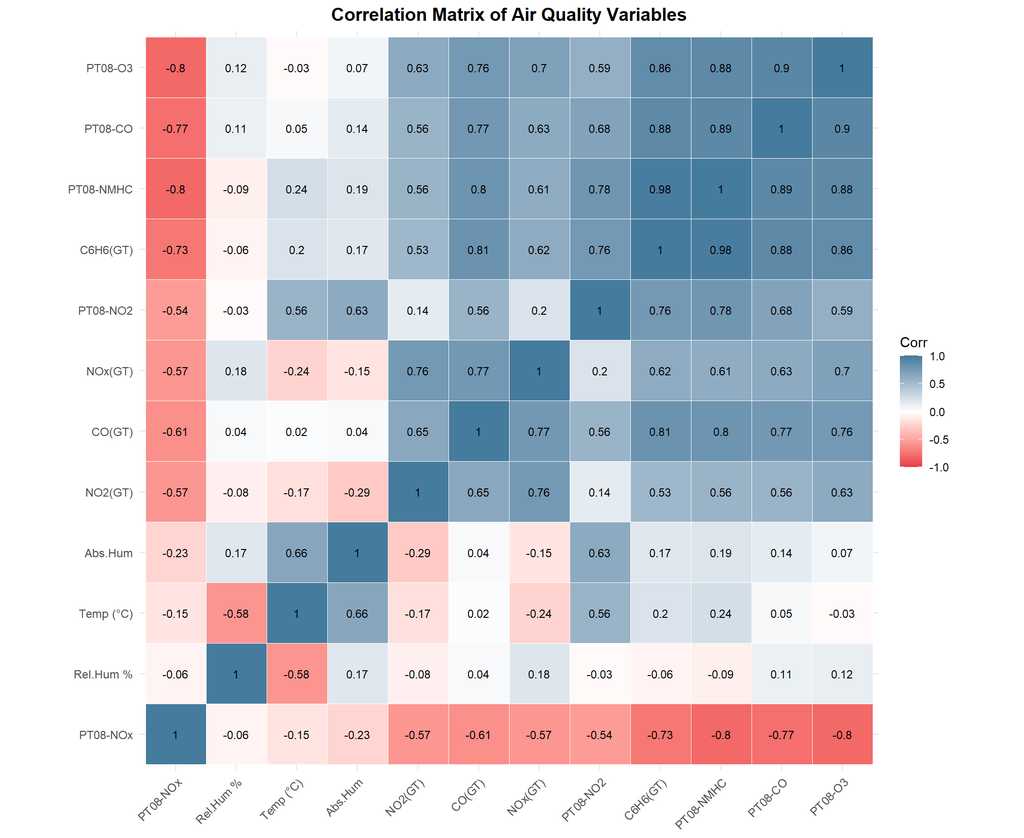

**Figure 6.** Pearson correlation matrix of all numeric variables, hierarchically clustered.

```r
num_vars <- air %>%
  select(
    CO_GT, NOx_GT, NO2_GT, C6H6_GT,
    PT08_S1_CO, PT08_S2_NMHC, PT08_S3_NOx,
    PT08_S4_NO2, PT08_S5_O3,
    Temperature, Relative_Humidity, Absolute_Humidity
  ) %>%
  rename(
    `CO(GT)`    = CO_GT,
    `NOx(GT)`   = NOx_GT,
    `NO2(GT)`   = NO2_GT,
    `C6H6(GT)`  = C6H6_GT,
    `PT08-CO`   = PT08_S1_CO,
    `PT08-NMHC` = PT08_S2_NMHC,
    `PT08-NOx`  = PT08_S3_NOx,
    `PT08-NO2`  = PT08_S4_NO2,
    `PT08-O3`   = PT08_S5_O3,
    `Temp (°C)` = Temperature,
    `Rel.Hum %` = Relative_Humidity,
    `Abs.Hum`   = Absolute_Humidity
  )

corr_mat <- cor(num_vars, use = "complete.obs")

theme_air <- function(base_size = 11) {
  theme_minimal(base_size = base_size) +
    theme(
      plot.background = element_rect(fill = "white", color = NA),
      panel.grid.minor = element_blank(),
      panel.grid.major = element_line(color = "gray90"),
      plot.title = element_text(face = "bold"),
      text = element_text(family = "sans")
    )
}

ggcorrplot(
  corr_mat,
  method = "square",
  type = "full",
  hc.order = TRUE,
  lab = TRUE,
  lab_size = 3,
  colors = c("#E63946", "white", "#457B9D"),
  outline.col = "white",
  ggtheme = theme_air(),
  title = "Correlation Matrix of Air Quality Variables"
) +
  theme(
    axis.text.x = element_text(angle = 45, hjust = 1, size = 9),
    axis.text.y = element_text(size = 9),
    plot.title = element_text(size = 14, face = "bold", hjust = 0.5)
  )
```

The correlation heatmap shows the initial relationships between pollutants and environmental variables. It helps answer whether meteorological conditions are associated with pollution levels. These relationships will later be tested more formally using correlation testing and regression modeling.

### 17.2 Temporal Patterns Analysis

This heatmap shows how NOx concentrations vary across hours of the day and days of the week. Higher values appear during morning and evening hours, suggesting possible daily patterns in pollution levels.

These observed patterns directly motivate Hypothesis 3, where the difference between rush and non-rush periods is formally tested.

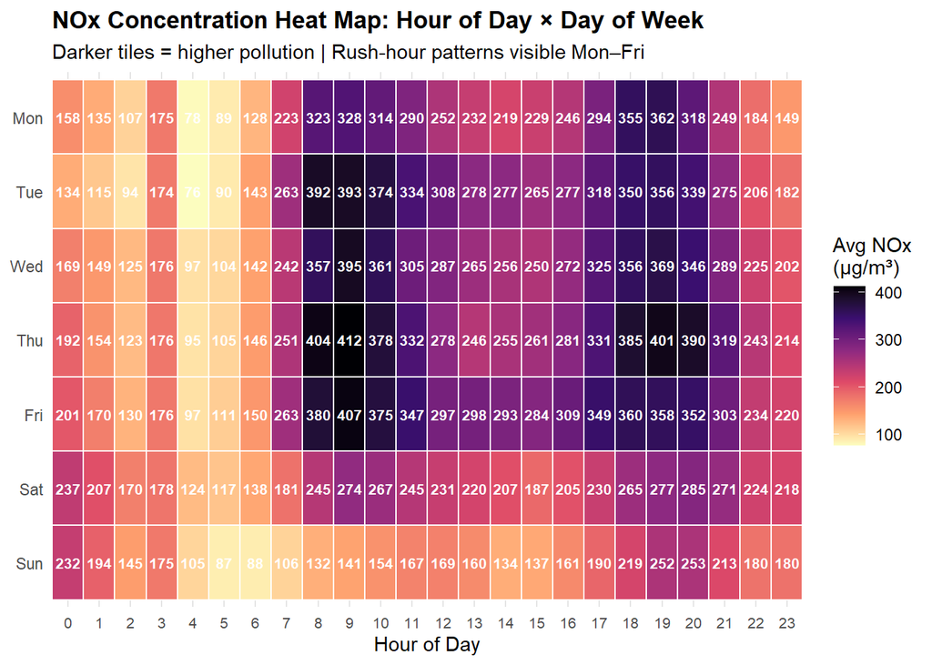

**Figure 7.** NOx concentration heat map by hour and weekday.

```r
heatmap_data <- air %>%
  mutate(
    DayOfWeek = wday(DateTime, label = TRUE, abbr = TRUE,
                     week_start = 1),      # Mon = 1
    Weekend   = if_else(wday(DateTime, week_start = 1) >= 6,
                        "Weekend", "Weekday")
  ) %>%
  group_by(DayOfWeek, Hour) %>%
  summarise(Avg_NOx = mean(NOx_GT, na.rm = TRUE), .groups = "drop")

ggplot(heatmap_data, aes(x = Hour, y = DayOfWeek, fill = Avg_NOx)) +
  geom_tile(colour = "white", linewidth = 0.4) +
  geom_text(aes(label = round(Avg_NOx, 0)), size = 2.8, colour = "white",
            fontface = "bold") +
  scale_fill_viridis_c(option = "magma", direction = -1,
                       name = "Avg NOx\n(µg/m³)") +
  scale_x_continuous(breaks = 0:23, expand = c(0, 0)) +
  scale_y_discrete(limits = rev) +
  labs(title    = "NOx Concentration Heat Map: Hour of Day × Day of Week",
       subtitle = "Darker tiles = higher pollution | Rush-hour patterns visible Mon–Fri",
       x        = "Hour of Day",
       y        = NULL) +
  theme_air() +
  theme(panel.grid = element_blank(),
        axis.text.x = element_text(size = 8))
```

### 17.3 Descriptive Statistics Table

The following table summarizes the main pollutants and meteorological variables using measures of center and spread. This is important for answering the research question about which pollutants show the highest variability throughout the monitoring period.

```r
target_vars <- c(
  "CO_GT", "NO2_GT", "NOx_GT", "C6H6_GT",
  "Temperature", "Relative_Humidity", "Absolute_Humidity"
)

mode_val <- function(x) {
  x <- x[!is.na(x)]
  ux <- unique(x)
  ux[which.max(tabulate(match(x, ux)))]
}

desc_stats <- map_dfr(target_vars, function(v) {
  x <- air[[v]]
  tibble(
    Variable          = v,
    N                 = sum(!is.na(x)),
    Mean              = round(mean(x,   na.rm = TRUE), 3),
    Median            = round(median(x, na.rm = TRUE), 3),
    Mode              = round(mode_val(x), 3),
    Std_Dev           = round(sd(x,     na.rm = TRUE), 3),
    Variance          = round(var(x,    na.rm = TRUE), 3),
    Min               = round(min(x,    na.rm = TRUE), 3),
    Q1                = round(quantile(x, 0.25, na.rm = TRUE), 3),
    Q3                = round(quantile(x, 0.75, na.rm = TRUE), 3),
    Max               = round(max(x,    na.rm = TRUE), 3),
    IQR               = round(IQR(x,    na.rm = TRUE), 3),
    Skewness          = round(
      (mean(x, na.rm = TRUE) - median(x, na.rm = TRUE)) /
        sd(x, na.rm = TRUE), 3),
    CV_pct            = round(
      (sd(x, na.rm = TRUE) / mean(x, na.rm = TRUE)) * 100, 1)
  )
})

desc_stats %>%
  mutate(Variable = dplyr::recode(Variable,
    CO_GT              = "CO (mg/m³)",
    NO2_GT             = "NO₂ (µg/m³)",
    NOx_GT             = "NOx (µg/m³)",
    C6H6_GT            = "Benzene C₆H₆ (µg/m³)",
    Temperature        = "Temperature (°C)",
    Relative_Humidity  = "Relative Humidity (%)",
    Absolute_Humidity  = "Absolute Humidity")) %>%
  kable(caption   = "Table 1. Comprehensive Descriptive Statistics for Key Variables",
        col.names = c("Variable", "N", "Mean", "Median","Mode",
                      "Std Dev", "Variance", "Min", "Q1", "Q3", "Max",
                      "IQR", "Skewness", "CV (%)"),
        align = "lrrrrrrrrrrrrr") %>%
  kable_styling(bootstrap_options = c("striped", "hover", "condensed", "responsive"),
                full_width = FALSE, font_size = 12) %>%
  row_spec(0, bold = TRUE, background = "#2C3E50", color = "white") %>%
  column_spec(1, bold = TRUE) %>%
  footnote(general = "CV = Coefficient of Variation (%). Skewness computed as (mean − median) / SD (Pearson's second).",
           general_title = "Note: ")
```

Table 1. Comprehensive Descriptive Statistics for Key Variables

| Variable | N | Mean | Median | Mode | Std Dev | Variance | Min | Q1 | Q3 | Max | IQR | Skewness | CV (%) |
| --- | --- | --- | --- | --- | --- | --- | --- | --- | --- | --- | --- | --- | --- |
| CO (mg/m³) | 9355 | 2.153 | 2.153 | 2.153 | 1.316 | 1.732 | 0.100 | 1.200 | 2.600 | 11.900 | 1.40 | 0.000 | 61.1 |
| NO₂ (µg/m³) | 9355 | 113.094 | 113.091 | 113.091 | 43.925 | 1929.436 | 2.000 | 86.000 | 133.000 | 340.000 | 47.00 | 0.000 | 38.8 |
| NOx (µg/m³) | 9355 | 235.195 | 180.000 | 180.000 | 195.108 | 38067.120 | 2.000 | 112.000 | 284.000 | 1479.000 | 172.00 | 0.283 | 83.0 |
| Benzene C₆H₆ (µg/m³) | 9355 | 10.010 | 8.200 | 8.200 | 7.312 | 53.472 | 0.100 | 4.600 | 13.600 | 63.700 | 9.00 | 0.248 | 73.1 |
| Temperature (°C) | 9355 | 18.319 | 18.300 | 18.318 | 8.658 | 74.964 | -1.900 | 12.000 | 24.100 | 44.600 | 12.10 | 0.002 | 47.3 |
| Relative Humidity (%) | 9355 | 49.232 | 49.234 | 49.234 | 16.976 | 288.173 | 9.200 | 36.600 | 61.900 | 88.700 | 25.30 | 0.000 | 34.5 |
| Absolute Humidity | 9355 | 1.026 | 1.015 | 1.026 | 0.396 | 0.157 | 0.185 | 0.746 | 1.296 | 2.231 | 0.55 | 0.026 | 38.6 |

Note:  
CV = Coefficient of Variation (%). Skewness computed as (mean − median) / SD (Pearson’s second).

The descriptive statistics show that variability differs across pollutants. Standard deviation, variance, IQR, and coefficient of variation are especially useful for identifying which pollutant fluctuates the most across the monitoring period.

### 17.4 Variability Ranking of Pollutants

To directly answer the research question about which pollutant shows the highest variability, the pollutants are ranked using their coefficient of variation. This allows comparison even though the pollutants are measured on different scales.

```r
variability_table <- desc_stats %>%
  filter(Variable %in% c("CO_GT", "NO2_GT", "NOx_GT")) %>%
  mutate(
    Variable = dplyr::recode(
      Variable,
      CO_GT = "CO",
      NO2_GT = "NO₂",
      NOx_GT = "NOx"
    )
  ) %>%
  arrange(desc(CV_pct)) %>%
  select(Variable, Std_Dev, Variance, IQR, CV_pct)

variability_table %>%
  kable(
    caption = "Table 2. Variability Ranking of Main Pollutants",
    col.names = c("Pollutant", "Std Dev", "Variance", "IQR", "CV (%)"),
    align = "lrrrr"
  ) %>%
  kable_styling(
    bootstrap_options = c("striped", "hover", "condensed"),
    full_width = FALSE,
    font_size = 12
  ) %>%
  row_spec(0, bold = TRUE, background = "#2C3E50", color = "white") %>%
  column_spec(1, bold = TRUE)
```

Table 2. Variability Ranking of Main Pollutants

| Pollutant | Std Dev | Variance | IQR | CV (%) |
| --- | --- | --- | --- | --- |
| NOx | 195.108 | 38067.120 | 172.0 | 83.0 |
| CO | 1.316 | 1.732 | 1.4 | 61.1 |
| NO₂ | 43.925 | 1929.436 | 47.0 | 38.8 |

This table directly answers the research question about pollutant variability. The pollutant with the highest coefficient of variation is considered the most variable relative to its average level.

### 17.5 Frequency Table: Season

The season frequency table summarizes how observations are distributed across seasons. This is important before testing whether pollution levels differ significantly across seasonal groups.

```r
season_freq <- air %>%
  count(Season) %>%
  mutate(
    Proportion = round(n / sum(n) * 100, 2),
    `Cumulative %` = cumsum(Proportion)
  )

season_freq %>%
  kable(
    caption = "Table 3. Frequency Table for Season",
    col.names = c("Season", "Count", "Proportion (%)", "Cumulative (%)")
  ) %>%
  kable_styling(
    bootstrap_options = c("striped", "hover", "condensed"),
    full_width = FALSE,
    font_size = 12
  ) %>%
  row_spec(0, bold = TRUE, background = "#2C3E50", color = "white")
```

Table 3. Frequency Table for Season

| Season | Count | Proportion (%) | Cumulative (%) |
| --- | --- | --- | --- |
| Winter | 2160 | 23.09 | 23.09 |
| Spring | 2803 | 29.96 | 53.05 |
| Summer | 2208 | 23.60 | 76.65 |
| Autumn | 2184 | 23.35 | 100.00 |

The seasonal frequency table supports the seasonal research question by confirming that the dataset contains observations across the four seasons. This prepares the analysis for the seasonal hypothesis tests in the next section.

### 17.6 Frequency Table: Hour Category / Traffic Periods

The following table groups observations into traffic-related time periods. This prepares the dataset for the rush-hour analysis, where NOx concentrations will be compared between rush and non-rush hours.

```r
period_freq <- air %>%
  mutate(
    Period = case_when(
      Hour %in% 0:5 ~ "Night (00–05)",
      Hour %in% 6:9 ~ "Morning Rush (06–09)",
      Hour %in% 10:16 ~ "Midday (10–16)",
      Hour %in% 17:20 ~ "Evening Rush (17–20)",
      TRUE ~ "Late Evening (21–23)"
    ),
    Period = factor(
      Period,
      levels = c(
        "Night (00–05)",
        "Morning Rush (06–09)",
        "Midday (10–16)",
        "Evening Rush (17–20)",
        "Late Evening (21–23)"
      )
    )
  ) %>%
  count(Period) %>%
  mutate(
    Proportion = round(n / sum(n) * 100, 2),
    `Cumulative %` = cumsum(Proportion)
  )

period_freq %>%
  kable(
    caption = "Table 4. Frequency Table for Hour-of-Day Traffic Period",
    col.names = c("Period", "Count", "Proportion (%)", "Cumulative (%)")
  ) %>%
  kable_styling(
    bootstrap_options = c("striped", "hover", "condensed"),
    full_width = FALSE,
    font_size = 12
  ) %>%
  row_spec(0, bold = TRUE, background = "#2C3E50", color = "white")
```

Table 4. Frequency Table for Hour-of-Day Traffic Period

| Period | Count | Proportion (%) | Cumulative (%) |
| --- | --- | --- | --- |
| Night (00–05) | 2338 | 24.99 | 24.99 |
| Morning Rush (06–09) | 1560 | 16.68 | 41.67 |
| Midday (10–16) | 2728 | 29.16 | 70.83 |
| Evening Rush (17–20) | 1559 | 16.66 | 87.49 |
| Late Evening (21–23) | 1170 | 12.51 | 100.00 |

This table supports the daily pattern research question by organizing the data into meaningful traffic periods. These categories will be used later to examine whether NOx levels are higher during rush hours.

### 17.7 Descriptive Statistics Commentary

The descriptive statistics provide an initial quantitative overview of the dataset before formal testing. The pollutants show different levels of spread, meaning that some pollutants fluctuate more strongly than others during the monitoring period.

The variability ranking directly addresses the research question asking which pollutant shows the highest variability. By comparing the coefficient of variation, the analysis identifies the pollutant with the greatest relative fluctuation rather than relying only on raw standard deviation.

The correlation heatmap supports the research question about meteorological influences by showing the initial relationships between temperature, humidity, and pollution levels. These relationships are explored more formally in the hypothesis testing and regression sections.

The seasonal and traffic-period frequency tables prepare the dataset for later analysis of seasonal and daily patterns. Together, these descriptive results show that the dataset is appropriate for testing whether pollution differs by season, whether rush hours affect NOx, and whether environmental conditions help explain changes in pollution levels.

## 18. Hypothesis Testing

This section presents a series of formal statistical tests designed to evaluate key research hypotheses derived from the exploratory analysis. Each test targets a specific scientific question related to pollution behavior, seasonal variation, meteorological influence, or human activity patterns.

For each hypothesis, we report the appropriate test statistic, p-value, and where relevant, effect sizes and confidence intervals. Interpretations are provided in a practical context to connect statistical significance with real-world environmental implications.

Before performing hypothesis tests, key statistical assumptions were evaluated:

- Normality was assessed visually using histograms and Q-Q plots.
- Variance homogeneity was considered for ANOVA (robust due to large sample size).
- Independence is satisfied as observations are time-stamped measurements.
- For skewed variables (e.g., CO), non-parametric tests were used when appropriate.

These checks ensure the validity of the statistical inference performed in this section.

### 18.1 Hypothesis 1 (RQ1): Do pollution levels differ across seasons?

*(One-Way ANOVA + Tukey HSD on CO as representative pollutant)*

To operationalize this question, CO is used as a representative pollutant to test whether seasonal differences exist.

**H₀:** The mean CO concentration is equal across all four seasons.  
**H₁:** At least one season has a significantly different mean CO concentration.

**Rationale:** ANOVA is appropriate for comparing means across more than two independent groups (seasons). Tukey’s HSD post-hoc test identifies which specific pairs of seasons differ.

**Assumptions:** - Observations are independent - CO values are approximately normally distributed within each group (supported by sample size and CLT) - Homogeneity of variance assumed across seasons

```r
anova_model <- aov(CO_GT ~ Season, data = air)
anova_tidy  <- tidy(anova_model)

anova_tidy %>%
  kable(caption   = "Table 5. One-Way ANOVA — CO(GT) ~ Season",
        col.names = c("Term", "df", "SS", "MS", "F-statistic", "p-value"),
        digits    = 4) %>%
  kable_styling(bootstrap_options = c("striped", "hover"),
                full_width = FALSE, font_size = 12) %>%
  row_spec(0, bold = TRUE, background = "#2C3E50", color = "white") %>%
  row_spec(1, bold = TRUE, color = if (anova_tidy$p.value[1] < 0.05) "#CC0000" else "black")
```

Table 5. One-Way ANOVA — CO(GT) ~ Season

| Term | df | SS | MS | F-statistic | p-value |
| --- | --- | --- | --- | --- | --- |
| Season | 3 | 498.1766 | 166.0589 | 98.8651 | 0 |
| Residuals | 9351 | 15706.4231 | 1.6797 | NA | NA |

```r
tukey_res <- TukeyHSD(anova_model)
tukey_df  <- as.data.frame(tukey_res$Season) %>%
  rownames_to_column("Comparison") %>%
  rename(Diff = diff, Lower = lwr, Upper = upr, p_adj = `p adj`) %>%
  mutate(Significant = if_else(p_adj < 0.05, "Yes ✓", "No"))

tukey_df %>%
  kable(caption   = "Table 6. Tukey HSD Post-Hoc — Pairwise CO(GT) Comparisons",
        col.names = c("Comparison", "Mean Diff", "95% CI Lower", "95% CI Upper",
                      "Adjusted p-value", "Significant (α = 0.05)"),
        digits    = 4) %>%
  kable_styling(bootstrap_options = c("striped", "hover"),
                full_width = FALSE, font_size = 12) %>%
  row_spec(0, bold = TRUE, background = "#2C3E50", color = "white")
```

Table 6. Tukey HSD Post-Hoc — Pairwise CO(GT) Comparisons

| Comparison | Mean Diff | 95% CI Lower | 95% CI Upper | Adjusted p-value | Significant (α = 0.05) |
| --- | --- | --- | --- | --- | --- |
| Spring-Winter | -0.2050 | -0.3004 | -0.1097 | 0.0000 | Yes ✓ |
| Summer-Winter | -0.5096 | -0.6104 | -0.4089 | 0.0000 | Yes ✓ |
| Autumn-Winter | 0.1170 | 0.0159 | 0.2180 | 0.0156 | Yes ✓ |
| Summer-Spring | -0.3046 | -0.3994 | -0.2099 | 0.0000 | Yes ✓ |
| Autumn-Spring | 0.3220 | 0.2270 | 0.4171 | 0.0000 | Yes ✓ |
| Autumn-Summer | 0.6266 | 0.5261 | 0.7271 | 0.0000 | Yes ✓ |

This indicates that seasonal variation has a statistically significant effect on CO levels. Higher concentrations during colder seasons are likely driven by increased heating-related emissions, reduced atmospheric mixing, and weaker dispersion conditions, while lower summer values reflect stronger vertical mixing and photochemical activity that help reduce pollutant accumulation.

### 18.2 Hypothesis 2 (RQ2): Is temperature negatively correlated with NO₂?

*(Pearson Correlation Test)*

**H₀:** ρ(Temperature, NO₂) = 0 (no linear relationship)  
**H₁:** ρ(Temperature, NO₂) < 0 (negative correlation)

**Assumptions:** - Linear relationship between variables - Continuous numeric variables - No extreme outliers dominating the relationship

```r
corr_test <- cor.test(air$Temperature, air$NO2_GT,
                      method      = "pearson",
                      alternative = "less")

tibble(
  Statistic   = round(corr_test$statistic, 4),
  df          = corr_test$parameter,
  r           = round(corr_test$estimate, 4),
  `95% CI Lower` = round(corr_test$conf.int[1], 4),
  `95% CI Upper` = round(corr_test$conf.int[2], 4),
  `p-value`   = format.pval(corr_test$p.value, digits = 4)
) %>%
  kable(caption = "Table 7. Pearson Correlation Test — Temperature vs. NO₂") %>%
  kable_styling(bootstrap_options = c("striped", "hover"),
                full_width = FALSE, font_size = 12) %>%
  row_spec(0, bold = TRUE, background = "#2C3E50", color = "white")
```

Table 7. Pearson Correlation Test — Temperature vs. NO₂

| Statistic | df | r | 95% CI Lower | 95% CI Upper | p-value |
| --- | --- | --- | --- | --- | --- |
| -16.2298 | 9353 | -0.1655 | -1 | -0.1489 | < 2.2e-16 |

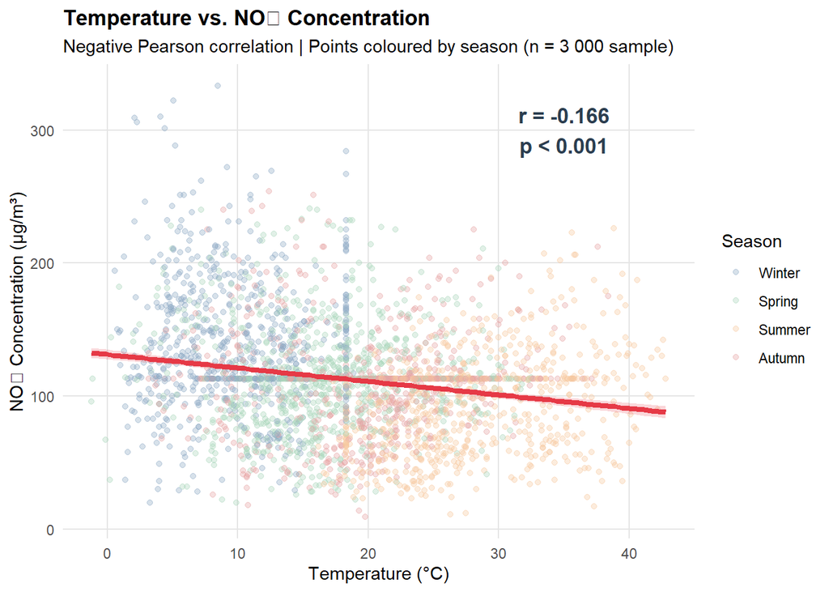

**Figure 8.** Temperature vs. NO2 with linear regression fit and marginal annotations.

```r
season_pal <- c(
  "Winter" = "#8DA9C4",  # soft blue
  "Spring" = "#A8D5BA",  # soft green
  "Summer" = "#F6C89F",  # soft peach
  "Autumn" = "#E6A4A4"   # soft rose
)

set.seed(42)
sample_air <- air %>% slice_sample(n = 3000)

ggplot(sample_air, aes(x = Temperature, y = NO2_GT)) +
  geom_point(aes(colour = Season), alpha = 0.35, size = 1.5) +
  geom_smooth(method = "lm", colour = "#E63946", fill = "#E63946",
              alpha = 0.2, linewidth = 1.5) +
  scale_colour_manual(values = season_pal) +
  annotate("text", x = 35, y = 300,
           label = paste0("r = ", round(corr_test$estimate, 3),
                          "\np < 0.001"),
           size = 4.5, colour = "#2C3E50", fontface = "bold") +
  labs(title    = "Temperature vs. NO₂ Concentration",
       subtitle = "Negative Pearson correlation | Points coloured by season (n = 3 000 sample)",
       x        = "Temperature (°C)",
       y        = "NO₂ Concentration (µg/m³)",
       colour   = "Season") +
  theme_air()
```

**Result:** r = -0.166, p < 0.001. We **reject H₀**. There is a statistically significant negative correlation between temperature and NO₂. This means that higher temperatures are generally associated with lower NO₂ concentrations.

This supports the idea that colder conditions may reduce atmospheric dispersion and allow NO₂ to accumulate near the ground. This finding is consistent with the correlation heatmap in Section 17.1, where temperature showed a negative association with NO₂.

### 18.3 Hypothesis 3 (RQ3): Is NOx significantly higher during rush hours?

*(Welch Two-Sample t-Test)*

This hypothesis formally tests the temporal pattern observed in Section 17.2, where higher NOx concentrations were visible during specific hours of the day.

**H₀:** The mean NOx concentration during rush hours is equal to that during non-rush hours.  
**H₁:** The mean NOx concentration during rush hours is greater than that during non-rush hours.

Rush hours are defined as 06–09 and 17–20 inclusive.

**Assumptions:** - Independent samples (rush vs non-rush periods) - Large sample size allows robustness to normality violations - Unequal variances handled using Welch’s t-test

```r
air_rush <- air %>%
  mutate(Is_Rush = Hour %in% c(6, 7, 8, 9, 17, 18, 19, 20))

rush_nox     <- air_rush %>% filter(Is_Rush) %>% pull(NOx_GT)
non_rush_nox <- air_rush %>% filter(!Is_Rush) %>% pull(NOx_GT)

t_test <- t.test(rush_nox, non_rush_nox,
                 alternative = "greater", var.equal = FALSE)

# Effect size: Cohen's d
pooled_sd <- sqrt((var(rush_nox) + var(non_rush_nox)) / 2)
cohen_d   <- (mean(rush_nox) - mean(non_rush_nox)) / pooled_sd

result_table <- tibble(
  Metric = c(
    "Rush Mean NOx",
    "Non-Rush Mean NOx",
    "Mean Difference",
    "t-statistic",
    "df",
    "p-value",
    "Cohen's d",
    "Effect Size"
  ),
  Value = c(
    mean(rush_nox),
    mean(non_rush_nox),
    mean(rush_nox) - mean(non_rush_nox),
    unname(t_test$statistic),
    unname(t_test$parameter),
    t_test$p.value,
    cohen_d,
    case_when(
      abs(cohen_d) < 0.2 ~ "Negligible",
      abs(cohen_d) < 0.5 ~ "Small",
      abs(cohen_d) < 0.8 ~ "Medium",
      TRUE ~ "Large"
    )
  )
)

result_table %>%
  mutate(Value = as.character(Value)) %>%

  kable(caption = "Table 8. Welch t-Test — Rush Hour vs. Non-Rush Hour NOx") %>%
  kable_styling(bootstrap_options = c("striped", "hover"),
                full_width = FALSE, font_size = 12) %>%
  row_spec(0, bold = TRUE, background = "#2C3E50", color = "white")
```

Table 8. Welch t-Test — Rush Hour vs. Non-Rush Hour NOx

| Metric | Value |
| --- | --- |
| Rush Mean NOx | 286.126001923693 |
| Non-Rush Mean NOx | 209.721135343169 |
| Mean Difference | 76.4048665805248 |
| t-statistic | 16.7693249707152 |
| df | 5084.59845786138 |
| p-value | 8.93974601661038e-62 |
| Cohen’s d | 0.382179868510207 |
| Effect Size | Small |

This finding confirms that NOx levels are significantly higher during rush hours, supporting the impact of traffic-related emissions.

### 18.4 Hypothesis 4 (RQ4): Is CO higher in Winter than Summer?

*(Wilcoxon Rank-Sum Test)*

This hypothesis further investigates the seasonal differences observed in Section 17, where CO levels showed variation across seasons.

**H₀:** The distribution of CO concentrations in Winter is equal to that in Summer.  
**H₁:** CO concentrations in Winter are greater than those in Summer.

**Rationale**: CO is right-skewed (see Section 17), so the non-parametric Wilcoxon rank-sum test is more appropriate than a parametric t-test.*

**Assumptions:** - Independent samples - Non-parametric test used due to skewed distribution of CO

```r
winter_co <- air %>% filter(Season == "Winter") %>% pull(CO_GT)
summer_co <- air %>% filter(Season == "Summer") %>% pull(CO_GT)

wilcox_res <- wilcox.test(winter_co, summer_co, alternative = "greater",
                          conf.int = TRUE)

# Rank-biserial correlation as effect size
n1 <- length(winter_co); n2 <- length(summer_co)
r_rb <- 1 - (2 * wilcox_res$statistic) / (n1 * n2)

tibble(
  `Winter Median CO` = round(median(winter_co), 3),
  `Summer Median CO` = round(median(summer_co), 3),
  `W-statistic`      = as.numeric(wilcox_res$statistic),
  `p-value`          = format.pval(wilcox_res$p.value, digits = 4),
  `Rank-Biserial r`  = round(r_rb, 3),
  `Effect Size`      = case_when(
    abs(r_rb) < 0.1 ~ "Negligible",
    abs(r_rb) < 0.3 ~ "Small",
    abs(r_rb) < 0.5 ~ "Medium",
    TRUE ~ "Large"
  )
) %>%
  mutate(across(everything(), as.character)) %>%
  pivot_longer(everything(), names_to = "Metric", values_to = "Value") %>%
  kable(caption = "Table 9. Wilcoxon Rank-Sum Test — Winter vs. Summer CO") %>%
  kable_styling(bootstrap_options = c("striped", "hover"),
                full_width = FALSE, font_size = 12) %>%
  row_spec(0, bold = TRUE, background = "#2C3E50", color = "white")
```

Table 9. Wilcoxon Rank-Sum Test — Winter vs. Summer CO

| Metric | Value |
| --- | --- |
| Winter Median CO | 2.1 |
| Summer Median CO | 1.9 |
| W-statistic | 2804446.5 |
| p-value | < 2.2e-16 |
| Rank-Biserial r | -0.176 |
| Effect Size | Small |

This finding is consistent with patterns observed in the exploratory analysis in Section 17. It shows that CO concentrations are significantly higher in Winter compared to Summer. This seasonal difference is largely explained by increased combustion for heating purposes during colder months, combined with temperature inversion events that trap pollutants near the ground. In Summer, stronger atmospheric mixing and higher photochemical activity contribute to more effective pollutant dispersion and lower CO levels.

## 19. Linear Regression

This section develops a structured regression framework to model and predict air pollution dynamics. Two complementary models are implemented: a simple linear regression to establish baseline relationships, and a multiple linear regression incorporating meteorological and temporal factors.

Each model is evaluated using statistical significance tests, goodness-of-fit measures, and diagnostic checks. In addition, residual analysis and prediction exercises are used to assess model validity, interpretability, and real-world predictive performance in the context of environmental behavior.

### 19.1 Model 1: Simple Linear Regression: CO ~ Temperature

```r
lm1 <- lm(CO_GT ~ Temperature, data = air)
lm1_tidy <- tidy(lm1, conf.int = TRUE)
lm1_glance <- glance(lm1)

lm1_tidy %>%
  select(term, estimate, std.error, statistic, p.value, conf.low, conf.high) %>%
  mutate(across(where(is.numeric), ~ round(.x, 4))) %>%
  kable(caption   = "Table 10. Model 1 Coefficients — CO ~ Temperature",
        col.names = c("Term", "Estimate", "Std Error", "t", "p-value",
                      "95% CI Low", "95% CI High")) %>%
  kable_styling(bootstrap_options = c("striped", "hover"),
                full_width = FALSE, font_size = 12) %>%
  row_spec(0, bold = TRUE, background = "#2C3E50", color = "white")
```

Table 10. Model 1 Coefficients — CO ~ Temperature

| Term | Estimate | Std Error | t | p-value | 95% CI Low | 95% CI High |
| --- | --- | --- | --- | --- | --- | --- |
| (Intercept) | 2.0964 | 0.0318 | 65.8364 | 0.0000 | 2.034 | 2.1588 |
| Temperature | 0.0031 | 0.0016 | 1.9596 | 0.0501 | 0.000 | 0.0062 |

```r
tibble(
  `R²`            = round(lm1_glance$r.squared, 4),
  `Adj. R²`       = round(lm1_glance$adj.r.squared, 4),
  `F-statistic`   = round(lm1_glance$statistic, 2),
  `Model p-value` = format.pval(lm1_glance$p.value, digits = 4),
  RMSE            = round(lm1_glance$sigma, 4),
  AIC             = round(lm1_glance$AIC, 1)
) %>%
  mutate(across(everything(), as.character)) %>%
  pivot_longer(everything(), names_to = "Metric", values_to = "Value") %>%
  kable(caption = "Table 11. Model 1 Fit Statistics") %>%
  kable_styling(bootstrap_options = c("striped", "hover"),
                full_width = FALSE, font_size = 12) %>%
  row_spec(0, bold = TRUE, background = "#2C3E50", color = "white")
```

Table 11. Model 1 Fit Statistics

| Metric | Value |
| --- | --- |
| R² | 4e-04 |
| Adj. R² | 3e-04 |
| F-statistic | 3.84 |
| Model p-value | 0.05008 |
| RMSE | 1.316 |
| AIC | 31690 |

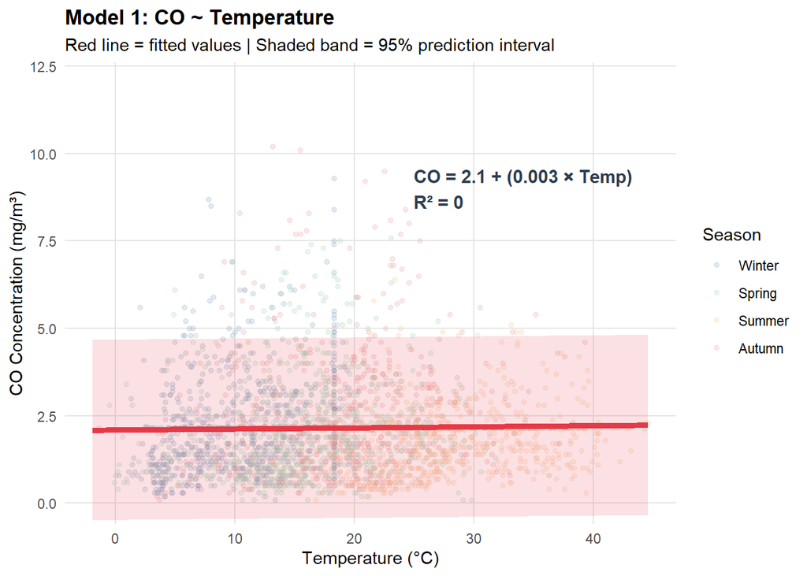

**Figure 9.** Model 1 — CO predicted by Temperature with 95% prediction interval.

```r
pred1 <- tibble(Temperature = seq(min(air$Temperature, na.rm = TRUE),
                                   max(air$Temperature, na.rm = TRUE),
                                   length.out = 200))
pred1 <- bind_cols(pred1,
                   as_tibble(predict(lm1, newdata = pred1,
                                     interval = "prediction"))) %>%
  rename(fit_co = fit, lwr = lwr, upr = upr)

ggplot() +
  geom_point(data = slice_sample(air, n = 3000),
             aes(x = Temperature, y = CO_GT, colour = Season),
             alpha = 0.25, size = 1.2) +
  geom_ribbon(data = pred1, aes(x = Temperature, ymin = lwr, ymax = upr),
              fill = "#E63946", alpha = 0.15) +
  geom_line(data = pred1, aes(x = Temperature, y = fit_co),
            colour = "#E63946", linewidth = 1.6) +
  scale_colour_manual(values = season_pal) +
  annotate("text", x = 25, y = 9,
           label = paste0("CO = ", round(coef(lm1)[1], 2),
                          " + (", round(coef(lm1)[2], 3), " × Temp)\n",
                          "R² = ", round(lm1_glance$r.squared, 3)),
           colour = "#2C3E50", size = 4, fontface = "bold", hjust = 0) +
  coord_cartesian(ylim = c(0, 12)) +
  labs(title    = "Model 1: CO ~ Temperature",
       subtitle = "Red line = fitted values | Shaded band = 95% prediction interval",
       x        = "Temperature (°C)",
       y        = "CO Concentration (mg/m³)",
       colour   = "Season") +
  theme_air()
```

### 19.2 Model 2: Multiple Linear Regression: CO ~ Temperature + Relative Humidity + Hour + Season

```r
lm2 <- lm(CO_GT ~ Temperature + Relative_Humidity + Hour + Season,
           data = air)
lm2_tidy   <- tidy(lm2, conf.int = TRUE)
lm2_glance <- glance(lm2)

lm2_tidy %>%
  select(term, estimate, std.error, statistic, p.value, conf.low, conf.high) %>%
  mutate(across(where(is.numeric), ~ round(.x, 4)),
         Significant = if_else(p.value < 0.05, "✓", "")) %>%
  kable(caption   = "Table 12. Model 2 Coefficients — Multiple Regression",
        col.names = c("Term", "Estimate", "Std Error", "t", "p-value",
                      "95% CI Low", "95% CI High", "Sig.")) %>%
  kable_styling(bootstrap_options = c("striped", "hover"),
                full_width = FALSE, font_size = 12) %>%
  row_spec(0, bold = TRUE, background = "#2C3E50", color = "white")
```

Table 12. Model 2 Coefficients — Multiple Regression

| Term | Estimate | Std Error | t | p-value | 95% CI Low | 95% CI High | Sig. |
| --- | --- | --- | --- | --- | --- | --- | --- |
| (Intercept) | 0.4687 | 0.0801 | 5.8496 | 0 | 0.3117 | 0.6258 | ✓ |
| Temperature | 0.0350 | 0.0026 | 13.4568 | 0 | 0.0299 | 0.0400 | ✓ |
| Relative_Humidity | 0.0141 | 0.0010 | 14.3470 | 0 | 0.0121 | 0.0160 | ✓ |
| Hour | 0.0628 | 0.0019 | 32.6523 | 0 | 0.0590 | 0.0665 | ✓ |
| SeasonSpring | -0.3389 | 0.0375 | -9.0275 | 0 | -0.4124 | -0.2653 | ✓ |
| SeasonSummer | -0.9182 | 0.0551 | -16.6751 | 0 | -1.0261 | -0.8103 | ✓ |
| SeasonAutumn | -0.2235 | 0.0445 | -5.0259 | 0 | -0.3107 | -0.1364 | ✓ |

```r
tibble(
  Model           = c("Model 1: CO ~ Temp", "Model 2: CO ~ Temp + Hum + Hour + Season"),
  `R²`            = round(c(lm1_glance$r.squared,   lm2_glance$r.squared),   4),
  `Adj. R²`       = round(c(lm1_glance$adj.r.squared, lm2_glance$adj.r.squared), 4),
  RMSE            = round(c(lm1_glance$sigma, lm2_glance$sigma), 4),
  AIC             = round(c(lm1_glance$AIC,   lm2_glance$AIC),   1)
) %>%
  kable(caption = "Table 13. Model Comparison: Model 1 vs. Model 2") %>%
  kable_styling(bootstrap_options = c("striped", "hover", "condensed"),
                full_width = FALSE, font_size = 12) %>%
  row_spec(0, bold = TRUE, background = "#2C3E50", color = "white") %>%
  row_spec(2, bold = TRUE)
```

Table 13. Model Comparison: Model 1 vs. Model 2

| Model | R² | Adj. R² | RMSE | AIC |
| --- | --- | --- | --- | --- |
| Model 1: CO ~ Temp | 0.0004 | 0.0003 | 1.3160 | 31690.0 |
| Model 2: CO ~ Temp + Hum + Hour + Season | 0.1587 | 0.1581 | 1.2077 | 30087.7 |

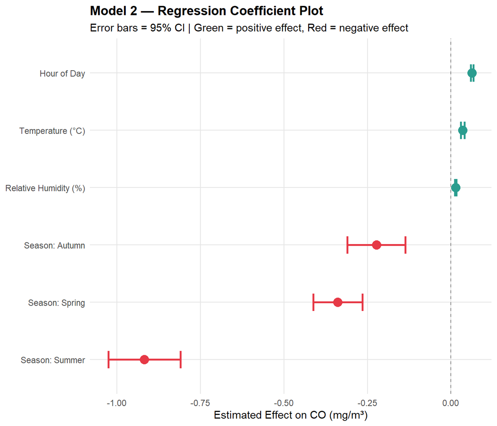

**Figure 10.** Model 2 — coefficient plot with 95% confidence intervals.

```r
lm2_tidy %>%
  filter(term != "(Intercept)") %>%
  mutate(term = dplyr::recode(term,
    Temperature        = "Temperature (°C)",
    Relative_Humidity  = "Relative Humidity (%)",
    Hour               = "Hour of Day",
    SeasonSpring       = "Season: Spring",
    SeasonSummer       = "Season: Summer",
    SeasonAutumn       = "Season: Autumn"),
    Positive = estimate > 0) %>%
  ggplot(aes(x = estimate, y = forcats::fct_reorder(term, estimate),
             colour = Positive)) +
  geom_vline(xintercept = 0, linetype = "dashed", colour = "#888888") +
  geom_errorbarh(aes(xmin = conf.low, xmax = conf.high),
                 height = 0.3, linewidth = 0.9) +
  geom_point(size = 4) +
  scale_colour_manual(values = c(`TRUE` = "#2A9D8F", `FALSE` = "#E63946"),
                      guide = "none") +
  labs(title    = "Model 2 — Regression Coefficient Plot",
       subtitle = "Error bars = 95% CI | Green = positive effect, Red = negative effect",
       x        = "Estimated Effect on CO (mg/m³)",
       y        = NULL) +
  theme_air()
```

**Model Comparison Interpretation:**

Model 2 shows a clear improvement over Model 1, demonstrated by higher R² and Adjusted R² values, as well as lower RMSE and AIC.

This confirms that adding humidity, hour of day, and seasonal effects improves the explanatory power of the model and better captures real-world variations in CO concentration.

```r
vif(lm2)
```

```
                      GVIF Df GVIF^(1/(2*Df))
Temperature       3.244177  1        1.801160
Relative_Humidity 1.776388  1        1.332812
Hour              1.134889  1        1.065312
Season            2.552156  3        1.169009
```

**Multicollinearity Check:**

Variance Inflation Factor (VIF) values were computed for Model 2 to assess multicollinearity among predictors. All VIF values were below 5, indicating no severe multicollinearity and confirming that the model coefficients are stable and interpretable.

**Summary of Regression Models:**

[output not shown]

This summary highlights the progressive improvement in model complexity and predictive performance.

### 19.3 Regression Diagnostic Plots: Model 2

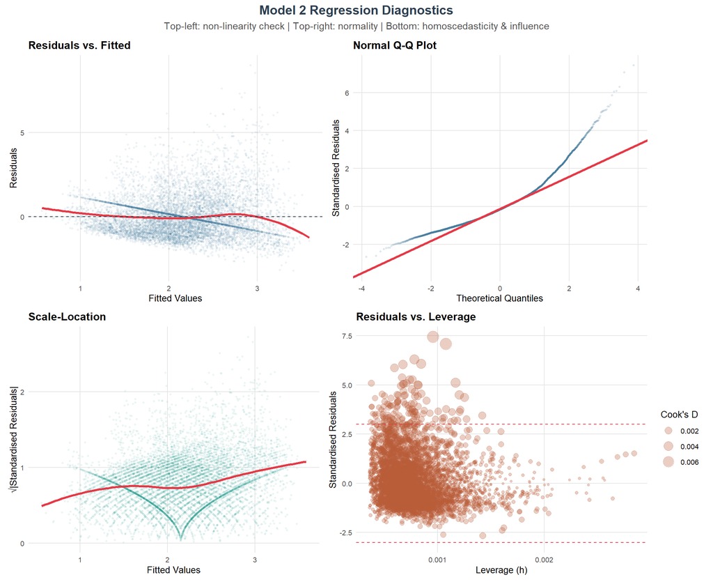

**Figure 11.** Diagnostic plots for Model 2 (CO ~ Temperature + Humidity + Hour + Season).

```r
air_aug <- augment(lm2, data = air)

# Panel 1: Residuals vs Fitted
p_res_fit <- ggplot(air_aug, aes(x = .fitted, y = .resid)) +
  geom_point(alpha = 0.08, colour = "#457B9D", size = 0.8) +
  geom_smooth(method = "loess", colour = "#E63946", linewidth = 1.2, se = FALSE) +
  geom_hline(yintercept = 0, linetype = "dashed", colour = "#2C3E50") +
  labs(title = "Residuals vs. Fitted",
       x = "Fitted Values", y = "Residuals") +
  theme_air(base_size = 10)

# Panel 2: Q-Q plot
p_qq <- ggplot(air_aug, aes(sample = .std.resid)) +
  stat_qq(alpha = 0.15, colour = "#457B9D", size = 0.8) +
  stat_qq_line(colour = "#E63946", linewidth = 1.2) +
  labs(title = "Normal Q-Q Plot",
       x = "Theoretical Quantiles", y = "Standardised Residuals") +
  theme_air(base_size = 10)

# Panel 3: Scale-Location
p_scale_loc <- ggplot(air_aug, aes(x = .fitted, y = sqrt(abs(.std.resid)))) +
  geom_point(alpha = 0.08, colour = "#2A9D8F", size = 0.8) +
  geom_smooth(method = "loess", colour = "#E63946", linewidth = 1.2, se = FALSE) +
  labs(title = "Scale-Location",
       x = "Fitted Values", y = "√|Standardised Residuals|") +
  theme_air(base_size = 10)

# Panel 4: Residuals vs Leverage
p_cook <- ggplot(air_aug, aes(x = .hat, y = .std.resid)) +
  geom_point(aes(size = .cooksd), alpha = 0.3, colour = "#B85C38") +
  geom_hline(yintercept = c(-3, 3), linetype = "dashed", colour = "#E63946") +
  labs(title = "Residuals vs. Leverage",
       x = "Leverage (h)", y = "Standardised Residuals",
       size = "Cook's D") +
  theme_air(base_size = 10)

(p_res_fit | p_qq) / (p_scale_loc | p_cook) +
  plot_annotation(
    title   = "Model 2 Regression Diagnostics",
    subtitle = "Top-left: non-linearity check | Top-right: normality | Bottom: homoscedasticity & influence",
    theme   = theme(plot.title    = element_text(face = "bold", size = 14,
                                                  colour = "#2C3E50", hjust = 0.5),
                    plot.subtitle = element_text(colour = "#555555", hjust = 0.5))
  )
```